# R Notebook

# Solutions

```r
suppressMessages(require(rms, quietly = TRUE, warn.conflicts = FALSE))
require(splines, quietly = TRUE)
require(plotly, quietly = TRUE, warn.conflicts = FALSE)
```

## Challenge 1

The first time you install a package within a new R session, you must select the CRAN mirror. Usually the best choice is the repository that is geographically closest to you. Once selected subsequent package installations will use this same server.

What command allows you to select a new CRAN mirror?

```r
chooseCRANmirror()
```

How do you manually specify the default repository?

```r
options(repos = "http://debian.mc.vanderbilt.edu/R/CRAN/")
```

## Challenge 2

```r
gender <- c('M','M','F','M','F','F','M','F','M')
age <- c(34, 64, 38, 63, 40, 73, 27, 51, 47)
smoker <- c('no','yes','no','no','yes','no','no','no','yes')
exercise <- factor(c('moderate','frequent','some','some','moderate','none',
                     'none','moderate','moderate'),
                    levels=c('none','some','moderate','frequent'), ordered=TRUE
)
los <- c(4,8,1,10,6,3,9,4,8)
x <- data.frame(gender, age, smoker, exercise, los)
```

1. Create a linear model using `x`, estimating the association between `los` and all remaining variables

```r
lm(los ~ gender + age + smoker + exercise, data=x)
```

```
Call:
lm(formula = los ~ gender + age + smoker + exercise, data = x)

Coefficients:
(Intercept)      genderM          age    smokeryes   exercise.L   exercise.Q   exercise.C
   0.588144     4.508675     0.033377     2.966623    -2.749852    -0.710942     0.002393
```

2. Create a new model, this time predicting `los` by `gender`; show the model summary

```r
f <- lm(los ~ gender)
summary(f)
```

```
Call:
lm(formula = los ~ gender)

Residuals:
   Min     1Q Median     3Q    Max
  -3.8   -0.5    0.2    1.2    2.5

Coefficients:
            Estimate Std. Error t value Pr(>|t|)
(Intercept)    3.500      1.099   3.186   0.0154 *
genderM        4.300      1.474   2.917   0.0224 *
---
Signif. codes:  0 ‘***’ 0.001 ‘**’ 0.01 ‘*’ 0.05 ‘.’ 0.1 ‘ ’ 1

Residual standard error: 2.197 on 7 degrees of freedom
Multiple R-squared:  0.5487,    Adjusted R-squared:  0.4842
F-statistic:  8.51 on 1 and 7 DF,  p-value: 0.02243
```

3. What is the estimate for the intercept? What is the estimate for gender?

```r
coef(f)
```

```
(Intercept)     genderM
        3.5         4.3
```

4. Re-calculate the standard errors, by taking the square root of the diagonal of the variance-covariance matrix of the summary of the linear model

```r
sqrt(diag(vcov(summary(f))))
```

```
(Intercept)     genderM
   1.098701    1.474061
```

5. Predict `los` with the following new data set

```r
newdat <- data.frame(gender=c('F','M','F'))
predict(f, newdat)
```

```
  1   2   3
3.5 7.8 3.5
```

6. Sum the square of the residuals of the model. Compare this to passing the model to the `deviance` function.

```r
sum(resid(f)^2)
```

```
[1] 33.8
```

```r
deviance(f)
```

```
[1] 33.8
```

7. Create a subset of `x` by taking all records where `gender` is ‘M’ and assigning it to the variable `men`. Do the same for the variable `women`.

```r
men <- x[x[,'gender'] == 'M',]
women <- x[x[,'gender'] == 'F',]
```

8. Call the `t.test` function, where the first argument is los for women and the second argument is los for men. Add the argument var.equal and set it to TRUE. Does this match the p-value computed in the model summary?

```r
t.test(women[,'los'], men[,'los'], var.equal=TRUE)
```

```
    Two Sample t-test

data:  women[, "los"] and men[, "los"]
t = -2.9171, df = 7, p-value = 0.02243
alternative hypothesis: true difference in means is not equal to 0
95 percent confidence interval:
 -7.7856014 -0.8143986
sample estimates:
mean of x mean of y
      3.5       7.8
```

## Challenge 3

```r
x <- seq(0, 3.5*pi, length=50)
dat <- data.frame(x = x, y = 4 * sin(x) + rnorm(length(x)))
```

1. Create a scatterplot of `dat`.

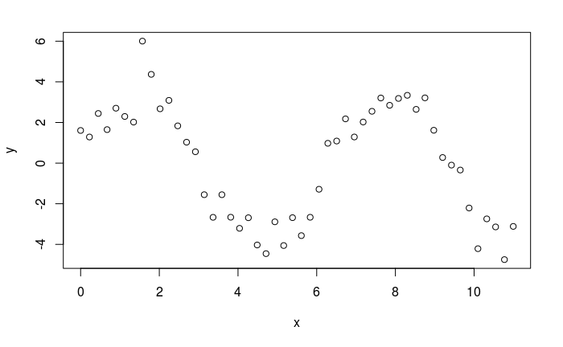

```r
plot(dat)
```

2. `f <- lm(y ~ ns(x,1), data = dat)` will create a linear model where `y` is predicted with a natural cubic spline of `x`; in this case it uses a spline with one degree of freedom. Create five models, increasing the degrees of freedom from 1 to 5.

```r
f1 <- lm(y ~ ns(x,1), data = dat)
f2 <- lm(y ~ ns(x,2), data = dat)
f3 <- lm(y ~ ns(x,3), data = dat)
f4 <- lm(y ~ ns(x,4), data = dat)
f5 <- lm(y ~ ns(x,5), data = dat)
```

3. Generate predicted values for the five models with the given data set.

```r
newdat <- data.frame(x=seq(x[1]*0.9, x[50]*1.1, length=50))
```

```r
p1 <- predict(f1, newdat)
p2 <- predict(f2, newdat)
p3 <- predict(f3, newdat)
p4 <- predict(f4, newdat)
p5 <- predict(f5, newdat)
```

4. Recreate the scatterplot of `dat`, but add lines for the predicted values (try it with base, ggplot, and plotly).

```r
plot(dat, xlim=range(newdat[,'x']))
lines(newdat[,'x'], p1, col=1)
```

```r
lines(newdat[,'x'], p2, col=2)
lines(newdat[,'x'], p3, col=3)
```

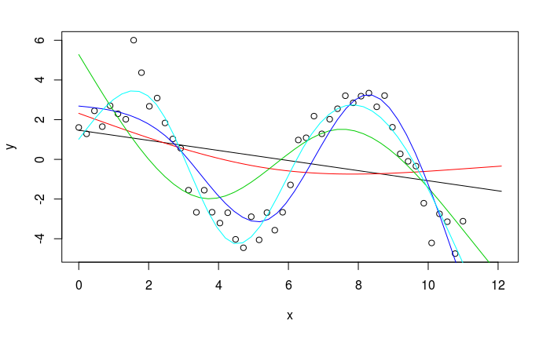

```r
lines(newdat[,'x'], p4, col=4)
lines(newdat[,'x'], p5, col=5)
```

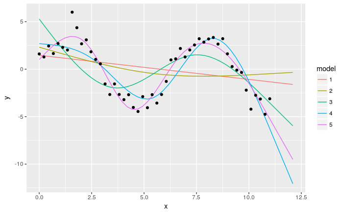

```r
predat <- data.frame(x=newdat[,'x'], y=c(p1, p2, p3, p4, p5), model=factor(rep(1:5, each=50)))
p <- ggplot(predat) + aes(x = x, y = y, color = model) + geom_line() + geom_point(data = dat, color='black')
p
```

```r
ggplotly(p)
```

[interactive chart not shown]

## Challenge 4

1. Retrieve the `titanic3` data set.

```r
getHdata(titanic3)
```

2. Describe the data.

```r
html(describe(titanic3))
```

titanic3  
14 Variables 1309 Observations

pclass

| n | missing | distinct |
| --- | --- | --- |
| 1309 | 0 | 3 |

```
 Value        1st   2nd   3rd
 Frequency    323   277   709
 Proportion 0.247 0.212 0.542
```

survived: Survived

| n | missing | distinct | Info | Sum | Mean | Gmd |
| --- | --- | --- | --- | --- | --- | --- |
| 1309 | 0 | 2 | 0.708 | 500 | 0.382 | 0.4725 |

name: Name

| n | missing | distinct |
| --- | --- | --- |
| 1309 | 0 | 1307 |

| lowest : | Abbing, Mr. Anthony | Abbott, Master. Eugene Joseph | Abbott, Mr. Rossmore Edward | Abbott, Mrs. Stanton (Rosa Hunt | Abelseth, Miss. Karen Marie |
| --- | --- | --- | --- | --- | --- |
| highest: | Zabour, Miss. Hileni | Zabour, Miss. Thamine | Zakarian, Mr. Mapriededer | Zakarian, Mr. Ortin | Zimmerman, Mr. Leo |

sex

| n | missing | distinct |
| --- | --- | --- |
| 1309 | 0 | 2 |

```
 Value      female   male
 Frequency     466    843
 Proportion  0.356  0.644
```

age: Age Year

| n | missing | distinct | Info | Mean | Gmd | .05 | .10 | .25 | .50 | .75 | .90 | .95 |
| --- | --- | --- | --- | --- | --- | --- | --- | --- | --- | --- | --- | --- |
| 1046 | 263 | 98 | 0.999 | 29.88 | 16.06 | 5 | 14 | 21 | 28 | 39 | 50 | 57 |

lowest : 0.1667 0.3333 0.4167 0.6667 0.7500 , highest: 70.5000 71.0000 74.0000 76.0000 80.0000

sibsp: Number of Siblings/Spouses Aboard

| n | missing | distinct | Info | Mean | Gmd |
| --- | --- | --- | --- | --- | --- |
| 1309 | 0 | 7 | 0.67 | 0.4989 | 0.777 |

```
 Value          0     1     2     3     4     5     8
 Frequency    891   319    42    20    22     6     9
 Proportion 0.681 0.244 0.032 0.015 0.017 0.005 0.007
```

parch: Number of Parents/Children Aboard

| n | missing | distinct | Info | Mean | Gmd |
| --- | --- | --- | --- | --- | --- |
| 1309 | 0 | 8 | 0.549 | 0.385 | 0.6375 |

```
 Value          0     1     2     3     4     5     6     9
 Frequency   1002   170   113     8     6     6     2     2
 Proportion 0.765 0.130 0.086 0.006 0.005 0.005 0.002 0.002
```

ticket: Ticket Number

| n | missing | distinct |
| --- | --- | --- |
| 1309 | 0 | 929 |

| lowest : | 110152 | 110413 | 110465 | 110469 | 110489 |
| --- | --- | --- | --- | --- | --- |
| highest: | W./C. 6607 | W./C. 6608 | W./C. 6609 | W.E.P. 5734 | WE/P 5735 |

fare: Passenger Fare British Pound (¤)

```
        n  missing distinct     Info     Mean      Gmd      .05      .10      .25
     1308        1      281        1     33.3    38.61    7.225    7.567    7.896
      .50      .75      .90      .95
   14.454   31.275   78.051  133.650
```

lowest : 0.0000 3.1708 4.0125 5.0000 6.2375 , highest: 227.5250 247.5208 262.3750 263.0000 512.3292

cabin

| n | missing | distinct |
| --- | --- | --- |
| 1309 | 0 | 187 |

lowest : A10 A11 A14 A16 , highest: F33 F38 F4 G6 T

embarked

| n | missing | distinct |
| --- | --- | --- |
| 1307 | 2 | 3 |

```
 Value        Cherbourg  Queenstown Southampton
 Frequency          270         123         914
 Proportion       0.207       0.094       0.699
```

boat

| n | missing | distinct |
| --- | --- | --- |
| 1309 | 0 | 28 |

lowest : 1 10 11 12 , highest: A B C C D D

body: Body Identification Number

| n | missing | distinct | Info | Mean | Gmd | .05 | .10 | .25 | .50 | .75 | .90 | .95 |
| --- | --- | --- | --- | --- | --- | --- | --- | --- | --- | --- | --- | --- |
| 121 | 1188 | 121 | 1 | 160.8 | 113 | 16 | 35 | 72 | 155 | 256 | 297 | 307 |

lowest : 1 4 7 9 14 , highest: 312 314 322 327 328

home.dest: Home/Destination

| n | missing | distinct |
| --- | --- | --- |
| 745 | 564 | 368 |

| lowest : | Aberdeen / Portland, OR | Albany, NY | Altdorf, Switzerland | Amenia, ND | Antwerp, Belgium / Stanton, OH |
| --- | --- | --- | --- | --- | --- |
| highest: | Worcester, England | Worcester, MA | Yoevil, England / Cottage Grove | Youngstown, OH | Zurich, Switzerland |

3. `naclus` can be used to examine missing data. Use it on the dataset and plot the results.

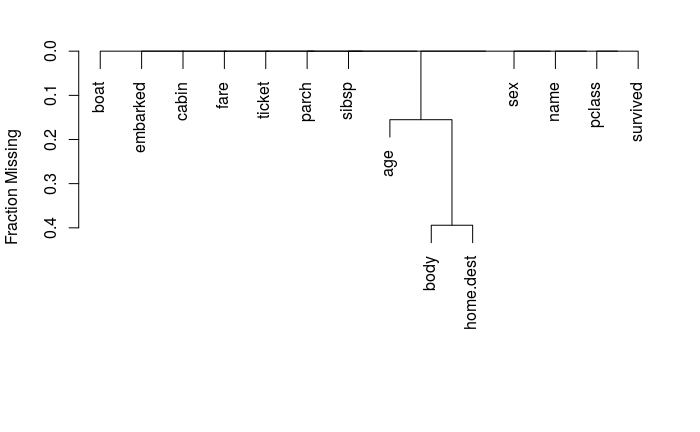

```r
plot(naclus(titanic3))
```

4. Describe `age`, `sex`, `pclass`, and `embarked` with the `summaryM` function while stratifying on `survived`. Show the output as a table and plot.

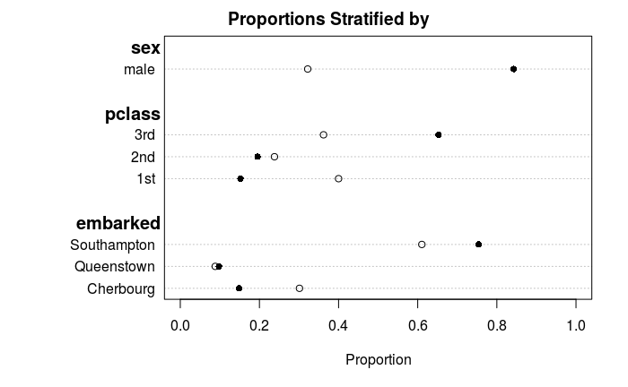

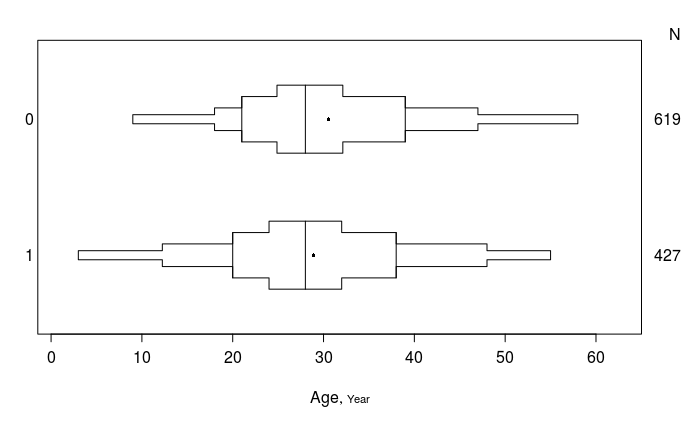

```r
s <- summaryM(age + sex + pclass + embarked ~ survived, data=titanic3)
plot(s)
```

```r
html(s)
```

| Descriptive Statistics *(N=1309)*. | Descriptive Statistics *(N=1309)*. N | Descriptive Statistics *(N=1309)*. 0 *N=809* | Descriptive Statistics *(N=1309)*. 1 *N=500* |
| --- | --- | --- | --- |
| Age Year | 1046 | 21 28 39 | 20 28 38 |
| sex : male | 1309 | 0.84 (682) | 0.32 (161) |
| pclass : 1st | 1309 | 0.15 (123) | 0.40 (200) |
| 2nd |  | 0.20 (158) | 0.24 (119) |
| 3rd |  | 0.65 (528) | 0.36 (181) |
| embarked : Cherbourg | 1307 | 0.15 (120) | 0.30 (150) |
| Queenstown |  | 0.10 ( 79) | 0.09 ( 44) |
| Southampton |  | 0.75 (610) | 0.61 (304) |

*a* *b* *c* represent the lower quartile *a*, the median *b*, and the upper quartile *c* for continuous variables. *N* is the number of non-missing values. Numbers after proportions are frequencies.

5. Use a logistic regression model (`lrm`) with the formula `survived ~ rcs(age,5)*sex+pclass`. `rcs(age,5)` indicates that age will be represented by a restricted cubic spline with five knots. Save the fit object as `f` and print it.

```r
dd <- datadist(titanic3)
options(datadist = "dd")
f <- lrm(survived ~ rcs(age,5)*sex+pclass, data=titanic3)
f
```

```
Frequencies of Missing Values Due to Each Variable
survived      age      sex   pclass
       0      263        0        0

Logistic Regression Model

 lrm(formula = survived ~ rcs(age, 5) * sex + pclass, data = titanic3)


                       Model Likelihood     Discrimination    Rank Discrim.
                          Ratio Test           Indexes           Indexes
 Obs          1046    LR chi2     465.62    R2       0.485    C       0.854
  0            619    d.f.            11    g        1.964    Dxy     0.708
  1            427    Pr(> chi2) <0.0001    gr       7.125    gamma   0.714
 max |deriv| 8e-08                          gp       0.347    tau-a   0.343
                                            Brier    0.144

                   Coef    S.E.   Wald Z Pr(>|Z|)
 Intercept          2.6792 0.5103  5.25  <0.0001
 age                0.0015 0.0404  0.04  0.9699
 age'              -0.0341 0.2444 -0.14  0.8891
 age''              0.2303 1.7373  0.13  0.8945
 age'''            -0.3131 2.5798 -0.12  0.9034
 sex=male           0.2338 0.6343  0.37  0.7124
 pclass=2nd        -1.3745 0.2434 -5.65  <0.0001
 pclass=3rd        -2.3129 0.2382 -9.71  <0.0001
 age * sex=male    -0.1892 0.0561 -3.37  0.0007
 age' * sex=male    0.7244 0.3320  2.18  0.0291
 age'' * sex=male  -4.1784 2.2962 -1.82  0.0688
 age''' * sex=male  5.1827 3.3417  1.55  0.1209
```

6. Obtain predictions for a data.frame that contains variables for `age`, `sex`, and `pclass`. Provide your own values for three or four observations. Pass the predicted values to `plogis` to perform a logistic transformation.

```r
dat <- expand.grid(age=30, sex=c('female','male'), pclass=c('1st','2nd'))
plogis(predict(f, dat))
```

```
        1         2         3         4
0.9301634 0.5549355 0.7711294 0.2397830
```

7. Plot the `nomogram` of the fit object. Add `fun=plogis` as an argument to `nomogram`.

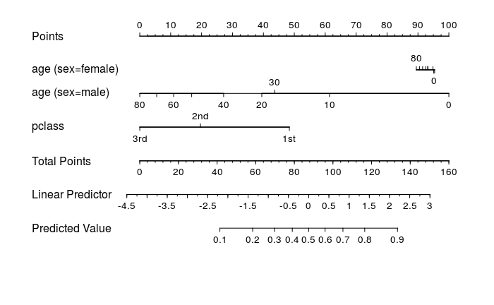

```r
plot(nomogram(f, fun=plogis))
```

8. Use `ggplot` and `Predict` to plot the predictors `age`, `sex`, and `pclass`. Include `fun=plogis` as an argument to `Predict`.

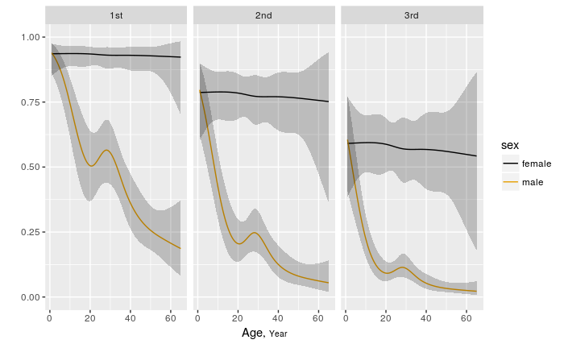

```r
ggplot(Predict(f, age, sex, pclass, fun=plogis))
```

## Challenge 5

The CDC has many available data sets. Take a look at the demographics data file for the [NHANES National Youth Fitness Survey](https://wwwn.cdc.gov/nchs/nhanes/search/nnyfsdata.aspx?Component=Demographics). This is an XPT file, or SAS export file. The code book can be viewed [here](https://wwwn.cdc.gov/Nchs/Nnyfs/Y_DEMO.htm).

1. Download, then import this dataset.

```r
dat <- foreign::read.xport("~/Downloads/Y_DEMO.XPT")
```

2. Keep only the following variables: `RIAGENDR, RIDAGEYR, INDHHIND2, DMDHHSIZ`. Describe the data.

```r
dat <- dat[,c('RIAGENDR','RIDAGEYR','INDHHIN2','DMDHHSIZ')]
html(describe(dat))
```

dat  
4 Variables 1640 Observations

RIAGENDR

| n | missing | distinct | Info | Mean | Gmd |
| --- | --- | --- | --- | --- | --- |
| 1640 | 0 | 2 | 0.75 | 1.498 | 0.5003 |

```
 Value          1     2
 Frequency    823   817
 Proportion 0.502 0.498
```

RIDAGEYR

| n | missing | distinct | Info | Mean | Gmd | .05 | .10 | .25 | .50 | .75 | .90 | .95 |
| --- | --- | --- | --- | --- | --- | --- | --- | --- | --- | --- | --- | --- |
| 1640 | 0 | 13 | 0.994 | 8.978 | 4.255 | 3 | 4 | 6 | 9 | 12 | 14 | 15 |

```
 Value          3     4     5     6     7     8     9    10    11    12    13    14
 Frequency    118   123   127   140   134   129   110   132   117   140   129   136
 Proportion 0.072 0.075 0.077 0.085 0.082 0.079 0.067 0.080 0.071 0.085 0.079 0.083

 Value         15
 Frequency    105
 Proportion 0.064
```

INDHHIN2

| n | missing | distinct | Info | Mean | Gmd | .05 | .10 | .25 | .50 | .75 | .90 | .95 |
| --- | --- | --- | --- | --- | --- | --- | --- | --- | --- | --- | --- | --- |
| 1634 | 6 | 16 | 0.988 | 10.98 | 8.935 | 2 | 3 | 5 | 8 | 14 | 15 | 15 |

```
 Value          1     2     3     4     5     6     7     8     9    10    12    13
 Frequency     44    57   100   101   138   171   117   101   110    82    63    23
 Proportion 0.027 0.035 0.061 0.062 0.084 0.105 0.072 0.062 0.067 0.050 0.039 0.014

 Value         14    15    77    99
 Frequency    158   325    26    18
 Proportion 0.097 0.199 0.016 0.011
```

DMDHHSIZ

| n | missing | distinct | Info | Mean | Gmd |
| --- | --- | --- | --- | --- | --- |
| 1640 | 0 | 6 | 0.937 | 4.612 | 1.38 |

```
 Value          2     3     4     5     6     7
 Frequency     50   233   572   384   251   150
 Proportion 0.030 0.142 0.349 0.234 0.153 0.091
```

3. Turn `RIAGENDR` into a factor variable with the proper value labels.

```r
dat[,'RIAGENDR'] <- factor(dat[,'RIAGENDR'], labels=c('Male','Female'))
```

4. Modify `INDHHIN2` by collapsing:
- 1,2,3,4,13 into 1
- 5,6,7,8 into 2
- 9,10,14 into 3
- 15 into 4
- 12,77,99 into NA

Then turn it into an ordered factor variable with the labels `$0-$19999, $20000-$54999, $55000-$99999, $100000+`.

```r
tmpinc <- dat[,'INDHHIN2']
tmpinc[tmpinc %in% c(1,2,3,4,13)] <- 1
tmpinc[tmpinc %in% c(5,6,7,8)] <- 2
tmpinc[tmpinc %in% c(9,10,14)] <- 3
tmpinc[tmpinc == 15] <- 4
tmpinc[!(tmpinc %in% c(1,2,3,4))] <- NA
dat[,'INDHHIN2'] <- factor(tmpinc,
                           labels=c('$0-$19999', '$20000-$54999', '$55000-$99999', '$100000+'),
                           ordered=TRUE)
```

5. Show the `table` of gender against age, and household income against size.

```r
with(dat, table(RIAGENDR, RIDAGEYR))
```

```
        RIDAGEYR
RIAGENDR  3  4  5  6  7  8  9 10 11 12 13 14 15
  Male   60 65 62 75 64 62 56 66 54 74 62 63 60
  Female 58 58 65 65 70 67 54 66 63 66 67 73 45
```

```r
with(dat, table(INDHHIN2, DMDHHSIZ))
```

```
               DMDHHSIZ
INDHHIN2          2   3   4   5   6   7
  $0-$19999      18  52  82  92  47  34
  $20000-$54999  21  81 184  75 105  61
  $55000-$99999   8  52 147  91  34  18
  $100000+        2  35 132  97  38  21
```

## Challenge 6

Suppose you have a sample of N=100 from the Gamma distribution with shape=2 and scale=1. Calculate the 75th percentile with a basic bootstrapped 95% confidence interval for the upper quartile (75th percentile).

```r
N <- 100
G <- rgamma(N, 2, 1)
# point estimate
PE <- quantile(G, 0.75)
# Bootstrap the 75th percentile
loops <- 1000
x <- numeric(loops)
for(i in seq(loops)) {
  x[i] <- quantile(sample(G, replace=TRUE), 0.75)
}
lb <- quantile(x, 0.025)
ub <- quantile(x, 0.975)
myCI <- unname(2 * PE - c(ub, lb))
myCI
```

```
[1] 2.015070 3.145078
```

Did the CI work?

```r
truth <- quantile(rgamma(1e6, 2, 1), 0.75)
truth > myCI[1] & truth < myCI[2]
```

```
 75%
TRUE
```

`boot` package solution

```r
require(boot, quietly = TRUE, warn.conflicts = FALSE)
boot.ci(boot(G, function(i, j) quantile(i[j], 0.75), R = 1000))
```

```
bootstrap variances needed for studentized intervals
```

```
BOOTSTRAP CONFIDENCE INTERVAL CALCULATIONS
Based on 1000 bootstrap replicates

CALL :
boot.ci(boot.out = boot(G, function(i, j) quantile(i[j], 0.75),
    R = 1000))

Intervals :
Level      Normal              Basic
95%   ( 2.195,  3.317 )   ( 2.015,  3.161 )

Level     Percentile            BCa
95%   ( 2.375,  3.521 )   ( 2.375,  3.521 )
Calculations and Intervals on Original Scale
```

## Challenge 7

https://fivethirtyeight.com/features/can-you-solve-these-colorful-puzzles/

You play a game with four balls: One ball is red, one is blue, one is green and one is yellow. They are placed in a box. You draw a ball out of the box at random and note its color. Without replacing the first ball, you draw a second ball and then paint it to match the color of the first. Replace both balls, and repeat the process. The game ends when all four balls have become the same color. What is the expected number of turns to finish the game?

Simulate the answer.

```r
draw <- function(x) sample(x)[c(1,1,3,4)]
test <- function(ii=c('r','b','g','y')) {
  i <- 1
  while(length(unique(ii<-draw(ii))) > 1) i <- i+1
  i
}
N <- 1000
ans <- numeric(N)
for(i in seq(N)) {
  ans[i] <- test()
}
mean(ans)
```

```
[1] 9.001
```